# 👮 Boston crime analysis

The goal of this study is to get an improved understanding of the offences that happen in Boston in order to enhance the policing strategy. We are going to answer the following questions :

- 🕑 What are the times and days are most affected by crime in Boston ?
- 🚨 What are the most frequent crimes in Boston ?
- 🗺️ Visualize using a map the amount of crimes depending their locations.

In order to do this, we will use the following [dataset](https://raw.githubusercontent.com/Rgts/Datasets/main/boston_crimes_2016_02.csv) made from governmental data.

⚠️ Seeing the different values that are present in our `Object` column, it looks like our dataset is more of a "police intervention" dataset than a "crime dataset". Let's create a `crime_df` that contains crime related interventions. For this, we will consider that objects in the following list are NOT crimes :

```
Property Lost, Investigate Person, Missing Person Located, Motor Vehicle Accident Response, Investigate Property, Medical Assistance, Property Found, Search Warrants, Recovered Stolen Property, Phone Call Complaints, Other
```

We are removing those items before working on our database.

## 1. 🧰 What are the times and days when that are most affected by crime ?

We need to find the relation between time, day and the amount of crimes.

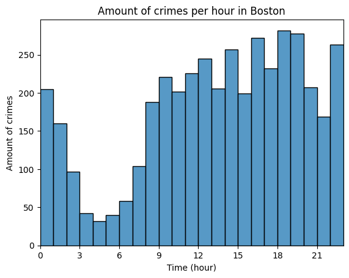

```python
sns.histplot(data=crime_df, x="Hour", binwidth=1)

# Set ticks of 3 hours on x axis
ax = plt.gca()
ax.set_xlim(0, 23)
ax.set_xticks(range(0, 24, 3))

# Add title and axis names
plt.title("Amount of crimes per hour in Boston")
plt.xlabel("Time (hour)")
plt.ylabel("Amount of crimes")
plt.show()
```

👉 Using an histogram seems pertinent here as we just need to count values groupped by a numeric value which is our time. We should try the same with the days.

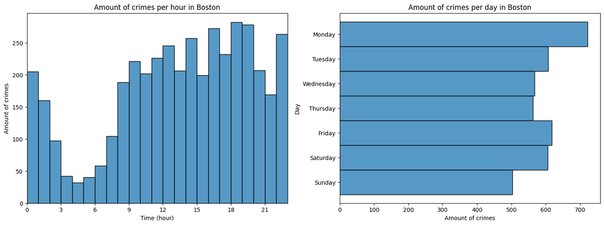

```python
fig, axs = plt.subplots(1, 2, figsize=(18, 6))

sns.histplot(data=crime_df, x="Hour", binwidth=1, ax=axs[0])

# Set ticks of 3 hours on x axis
axs[0].set_xlim(0, 23)
axs[0].set_xticks(range(0, 24, 3))

# Add title and axis names
axs[0].set_xlabel("Time (hour)")
axs[0].set_ylabel("Amount of crimes")
axs[0].set_title("Amount of crimes per hour in Boston")

sns.histplot(data=crime_df, y="Day", ax=axs[1])

# Add title and axis names
axs[1].set_title("Amount of crimes per day in Boston")
axs[1].set_xlabel("Amount of crimes")
axs[1].set_ylabel("Day")
plt.show()
```

💡 Crimes tend to happen more during the afternoon, between 4pm and 8pm. We can also observe that crimes happen more on Mondays.

## 2. 🚨 What are the most frequent crimes in Boston ?

Histograms are also quite useful to measure the frequency of a value across a DataFrame, let's try with one.

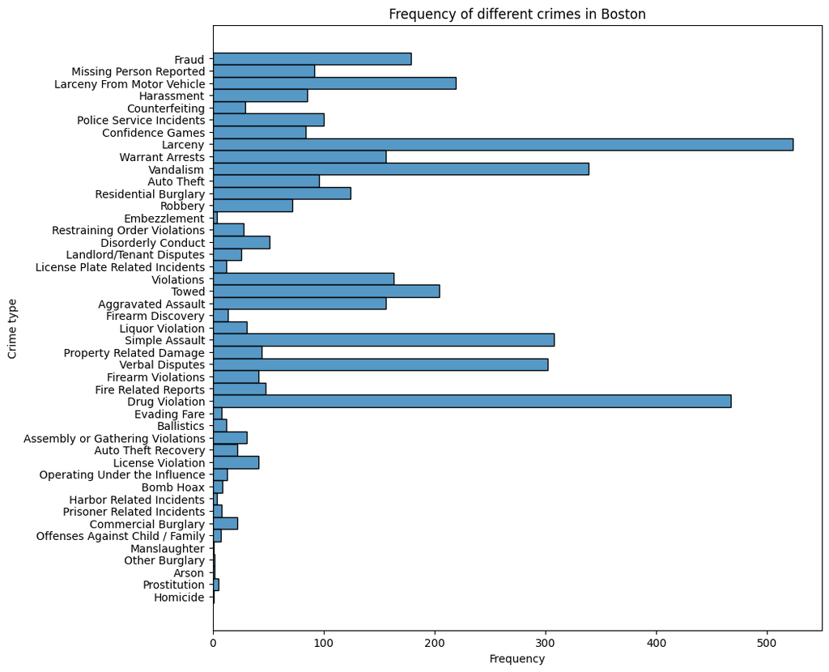

```python
plt.figure(figsize=(10, 10))

sns.histplot(data=crime_df, y="Object", stat="frequency", binwidth=1)

# Set title and axis names
plt.title("Frequency of different crimes in Boston")
plt.ylabel("Crime type")
plt.show()
```

👉 There are too much crime types for us to make a meaningful analysis, let's take the 10 most frequent crime types instead.

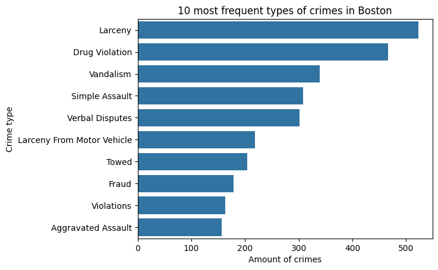

```python
# Create a new DataFrame with the top 10 crime types
top_crime_types = crime_df.groupby("Object").size().nlargest(10).index
top_crimes_df = crime_df.loc[df["Object"].isin(top_crime_types)]

sns.countplot(data=top_crimes_df, y="Object", order=top_crimes_df["Object"].value_counts().index)

# Set title and axis names
plt.title("10 most frequent types of crimes in Boston")
plt.xlabel("Amount of crimes")
plt.ylabel("Crime type")
plt.show()
```

💡 Obviously, the most frequent crimes in Boston are larceny drug diolation and vandalism.

## 🗺️ 3. Visualize using a map the amount of crimes depending their locations.

For this part, we will use `folium` and its `heatmap` to visualize crimes depending their locations.

```python
from collections import Counter

locations = crime_df[["Latitude", "Longitude"]]

# Instanciate KMeans algorithme to reduce the amount of spots on our heatmap
kmeans = KMeans(n_clusters=50, init="k-means++", max_iter=300, random_state=0)
kmeans.fit(locations)
label_counts = Counter(kmeans.labels_)

weights = [[*kmeans.cluster_centers_[i], label_counts[kmeans.labels_[i]]] for i in range(len(kmeans.cluster_centers_))]

# Compute mean location to center the map
mean_location = (crime_df["Latitude"].mean(), crime_df["Longitude"].mean())
map = folium.Map(location=mean_location, zoom_start=12)

HeatMap(weights).add_to(map)

map
```

Make this Notebook Trusted to load map: File -> Trust Notebook

[interactive chart not shown]